[figure not shown]

# **Análise Geoespacial em R Part 2**

Para trabalhar com dados raster em R, utilizamos o pacote raster, que oferece uma ampla gama de funções para a criação, leitura, manipulação e processamento de dados raster. Este pacote permite trabalhar eficientemente com grandes conjuntos de dados raster que podem ser grandes demais para caber na memória principal do computador. Em tais casos, o pacote raster oferece a possibilidade de processar os dados em partes menores, evitando a necessidade de carregar o arquivo raster completo na RAM.

```r
# Instalar biblioteca
#install.packages("raster", dependencies = TRUE)
#install.packages("sf",dependencies = TRUE)
#install.packages("terra",dependencies = TRUE)
#install.packages("marmap",dependencies = TRUE)
#install.packages("tmap",dependencies = TRUE)
#install.packages("tidyverse")
#install.packages("viridis")
```

```r
# Iportar bibliotecas
library(raster)
```

```r
library(ggplot2)
library(sf)
library(terra)
library(dplyr)
library(tmap)
library(tidyverse)
library(readr)
library(viridis)
unzip("D:/Pos-GeoDataScience/M2-R/dado_pratica/07S36_ZN.zip", exdir = "D:/Pos-GeoDataScience/M2-R/dado_pratica/raster")
```

```r
# Carregar dados geoespaciais
municipios <- st_read("D:/Pos-GeoDataScience/M2-R/dado_pratica/PB_Municipios/PB_Municipios_2022.shp")
joaoPessoa <- municipios %>% filter(municipios$NM_MUN == 'João Pessoa')
```

```r
# Ler dados raster
rasterData <- raster("D:/Pos-GeoDataScience/M2-R/dado_pratica/raster/07S36_ZN.tif", format = "GTiff")
rasterData
```

```
## class      : RasterLayer
## dimensions : 3600, 5400, 19440000  (nrow, ncol, ncell)
## resolution : 0.0002777785, 0.0002777776  (x, y)
## extent     : -36, -34.5, -8, -7  (xmin, xmax, ymin, ymax)
## crs        : +proj=longlat +datum=WGS84 +no_defs
## source     : 07S36_ZN.tif
## names      : X07S36_ZN
```

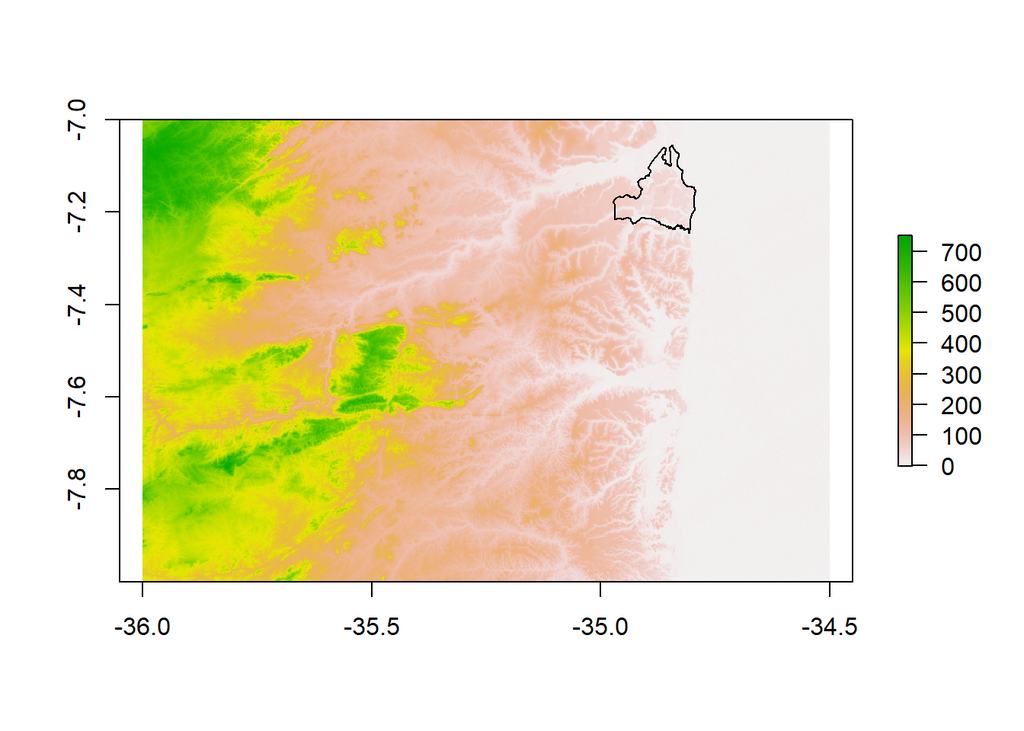

```r
plot(rasterData,)
plot(st_geometry(joaoPessoa$geometry), add = TRUE)
```

### **Recortar Image**

Para realizar o recorte de uma imagem raster no R, utilizando a geometria de um shapefile específico, você pode seguir os seguintes passos, adaptando o procedimento realizado em Python para o ambiente do R. A função equivalente a mask no pacote raster do R será usada para aplicar o recorte.

```r
# Recortar raster pelo polígono do município
rasterRecortado <- mask(rasterData, joaoPessoa)
joaoPessoa_sp <- as(joaoPessoa, "Spatial")

# Obtendo os limites da geometria do shapefile
xmin <- bbox(joaoPessoa_sp)[1,1]
xmax <- bbox(joaoPessoa_sp)[1,2]
ymin <- bbox(joaoPessoa_sp)[2,1]
ymax <- bbox(joaoPessoa_sp)[2,2]
```

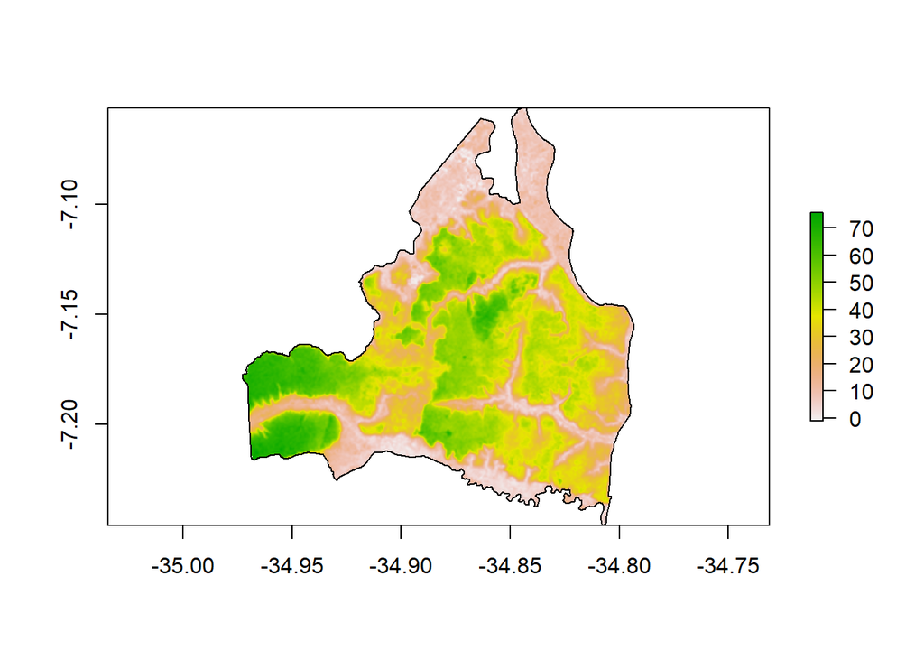

```r
# Visualizar dados
plot(rasterRecortado, xlim=c(xmin, xmax), ylim=c(ymin, ymax))
plot(st_geometry(joaoPessoa), add = TRUE)
```

### **Fatiamento e Reclassificação**

Para realizar o fatiamento e a reclassificação de um raster no R, você pode usar a função `reclassify()`. Essa função permite reclassificar os valores de um raster, transformando os valores originais em novas categorias com base em intervalos especificados.

```r
# Definir as regras de reclassificação
reclassRules <- matrix(c(-Inf, 0, NA,
                         0, 10, 1,
                         10, 60, 2,
                         60, 100, 3,
                         100, Inf, NA), byrow = TRUE, ncol = 3)
```

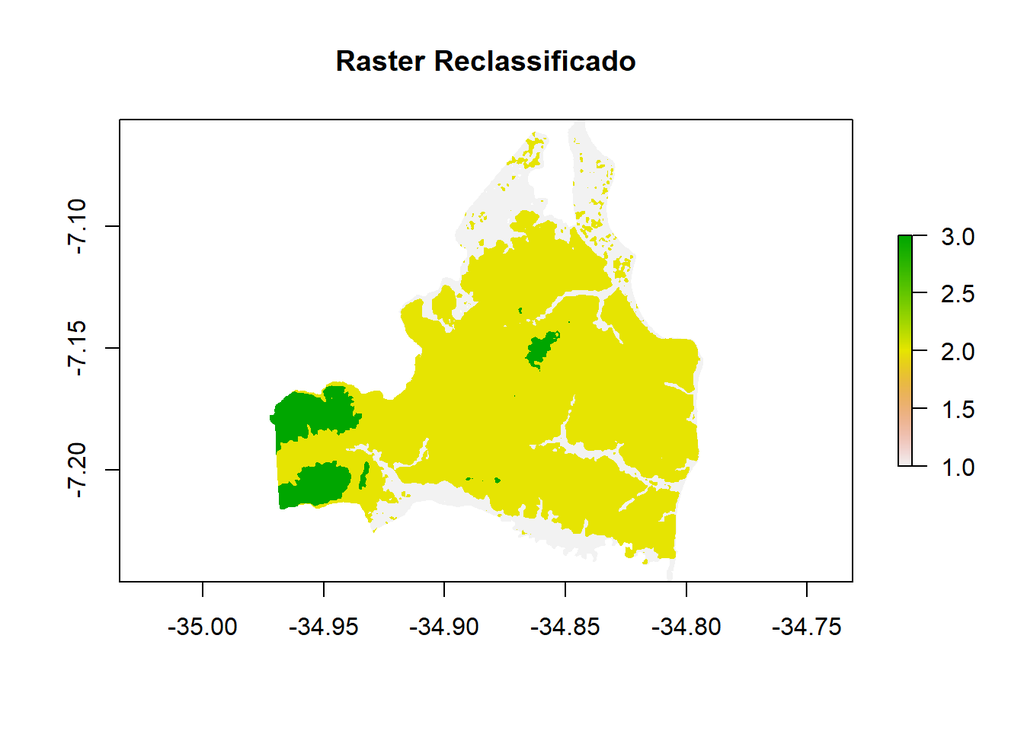

```r
# Aplicar a reclassificação
rasterReclassificado <- reclassify(rasterRecortado, reclassRules)

# Visualizar o raster reclassificado
plot(rasterReclassificado, main = "Raster Reclassificado", xlim=c(xmin, xmax), ylim=c(ymin, ymax))
```

### **Redimensionar**

```r
# Determinar o fator de agregação para alcançar aproximadamente a resolução desejada
fator <- sqrt(ncell(rasterReclassificado) / (50 * 50))

# Diminuir a resolução: Usar aggregate() para resolução mais baixa
rasterRedimensionado <- aggregate(rasterReclassificado, fact=fator)
```

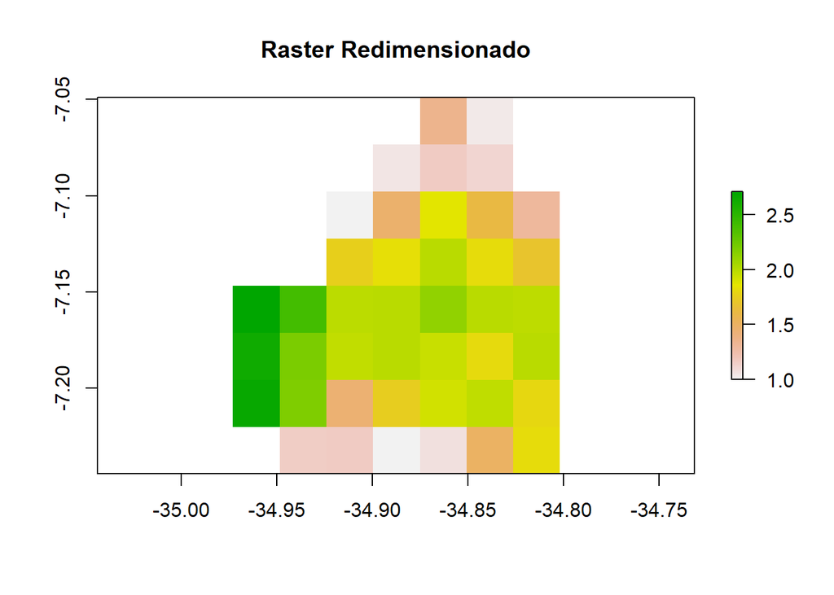

```r
# Visualizar o raster redimensionado
plot(rasterRedimensionado, main="Raster Redimensionado", xlim=c(xmin, xmax), ylim=c(ymin, ymax))
```

### **Mudar Sistema de Referências**

Também podemos realizar a Reprojeção com R, usando uma única função `projectRaster`.

```r
# Definir o sistema de referências
dest_crs <- "EPSG:3395" #WGS 84 / World Mercator

# Reprojetar o raster para o novo sistema de referências
raster_reprojetado <- projectRaster(rasterReclassificado, crs=dest_crs)
```

### **Salvar Imagens**

Todos os processamento que realizamos podem ser salvo também usando a função `writeRaster` para isso.

```r
# Definir o caminho de saída para o raster reprojetado
caminho_reprojetado <- "D:/Pos-GeoDataScience/M2-R/dado_pratica/raster/07S36_ZN_PROJECT.tif"

# Salvar o raster reprojetado
writeRaster(raster_reprojetado, caminho_reprojetado, overwrite=TRUE)
```

### **Dividir Imagem**

Subdividir uma imagem no R em bem parecido com o que vimos no Pthon. O processo segue a mesma lógica que fizemos anteriormente, onde o primeiro processo será encontrar as dimensões da nossa área de interesse e criar em seguida as partes da imagem.

```r
# Projetando regi'ao de interesse
joaoPessoa_project <- st_transform(joaoPessoa, crs = 3395)

# Obter a extensão total do raster
ext_total <- extent(joaoPessoa_project)

# Calcular o centro da extensão em X e Y
x_center <- ext_total@xmin + (ext_total@xmax - ext_total@xmin) / 2
y_center <- ext_total@ymin + (ext_total@ymax - ext_total@ymin) / 2

# Criar objetos de extensão para cada quadrante
ext_se <- extent(ext_total@xmin, x_center, ext_total@ymin, y_center)
ext_sd <- extent(x_center, ext_total@xmax, ext_total@ymin, y_center)
ext_ie <- extent(ext_total@xmin, x_center, y_center, ext_total@ymax)
ext_id <- extent(x_center, ext_total@xmax, y_center, ext_total@ymax)
```

```r
# Usar crop para criar cada parte
parte_superior_esquerda <- crop(raster_reprojetado, ext_se)
parte_superior_direita <- crop(raster_reprojetado, ext_sd)
parte_inferior_esquerda <- crop(raster_reprojetado, ext_ie)
parte_inferior_direita <- crop(raster_reprojetado, ext_id)
```

[figure not shown]

```r
par(mfrow=c(2,2))
plot(parte_superior_esquerda, main="Superiro Esquerdo")
plot(parte_superior_direita, main="Superior Direito")
plot(parte_inferior_esquerda, main="Inferior Esquerdo")
plot(parte_inferior_direita, main="Inferior Direita")
```

### **Mosaico**

Para combinar ou criar um mosaico com múltiplos rasters o procedimento geral seria feito com a função `merge`.

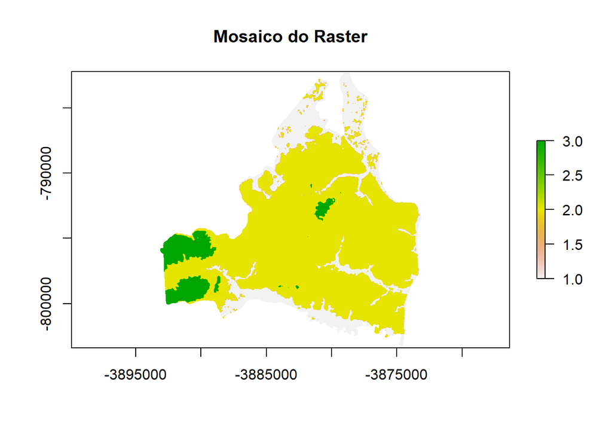

```r
# Exemplo usando merge para combinar duas partes
mosaico_superior <- merge(parte_superior_esquerda, parte_superior_direita)
mosaico_inferior <- merge(parte_inferior_esquerda, parte_inferior_direita)

# E depois combinando as duas metades
imagem_completa <- merge(mosaico_superior, mosaico_inferior, along = 2)

plot(imagem_completa, main = "Mosaico do Raster")
```

### **Operações Matemáticas**

No ambiente da linguagem R, uma ampla gama de operações pode ser executada em dados raster com eficiência e flexibilidade, especialmente através do uso do pacote `raster`.

```r
# 1. Normalização
normalized <- (rasterRecortado - minValue(rasterRecortado)) / (maxValue(rasterRecortado) - minValue(rasterRecortado))

# 2. Logaritmo
log_transformed <- log1p(rasterRecortado)
# 3. Exponencial
exponential_transformed <- exp(rasterRecortado)

# 4. Inversão de Valores
inverted <- maxValue(rasterRecortado) - rasterRecortado
```

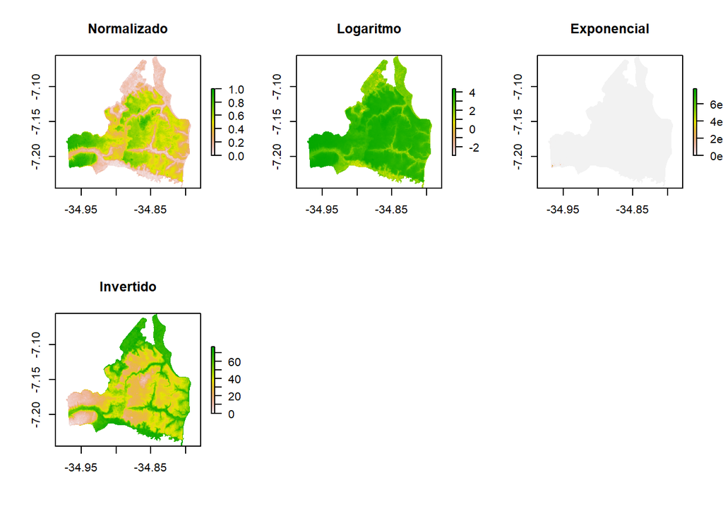

```r
# Para visualização, você pode usar o par(mfrow=c(n,m)) para organizar os plots e plot para visualizar cada raster
par(mfrow=c(2,3))
plot(normalized, main="Normalizado", xlim=c(xmin, xmax), ylim=c(ymin, ymax))
plot(log_transformed, main="Logaritmo", xlim=c(xmin, xmax), ylim=c(ymin, ymax))
plot(exponential_transformed, main="Exponencial", xlim=c(xmin, xmax), ylim=c(ymin, ymax))
plot(inverted, main="Invertido", xlim=c(xmin, xmax), ylim=c(ymin, ymax))
```

```r
# Outras operações:
soma_constante <- rasterRecortado + 150
adicao_imagens <- rasterRecortado + inverted
media_imagens <- (rasterRecortado + rasterRecortado) / 2
multiplicacao_constante <- rasterRecortado * 10
multiplicacao_imagens <- rasterRecortado * rasterRecortado
```

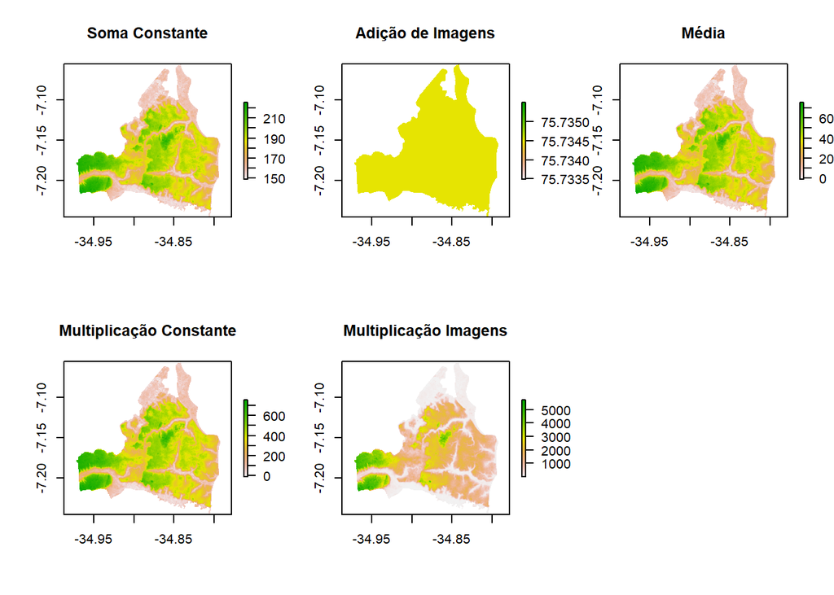

```r
par(mfrow=c(2,3))
plot(soma_constante, main="Soma Constante", xlim=c(xmin, xmax), ylim=c(ymin, ymax))
plot(adicao_imagens, main="Adição de Imagens", xlim=c(xmin, xmax), ylim=c(ymin, ymax))
plot(media_imagens, main="Média", xlim=c(xmin, xmax), ylim=c(ymin, ymax))
plot(multiplicacao_constante, main="Multiplicação Constante", xlim=c(xmin, xmax), ylim=c(ymin, ymax))
plot(multiplicacao_imagens, main="Multiplicação Imagens", xlim=c(xmin, xmax), ylim=c(ymin, ymax))
```

### **Raster to Polygon e rasterize**

No R para realizar a conversão de raster para polígonos e vice-versa, podemos utilizar o mesmo pacote `raster` em conjunto com `sf`. Entretanto, diferente do Python no R é bem mais fácil, podemos realizar a operação tulizando somente uma função.

```r
poligonos <- rasterToPolygons(rasterReclassificado, fun=function(x){x==1},
                              na.rm=TRUE)
head(poligonos)
```

```
##   X07S36_ZN
## 1         1
## 2         1
## 3         1
## 4         1
## 5         1
## 6         1
```

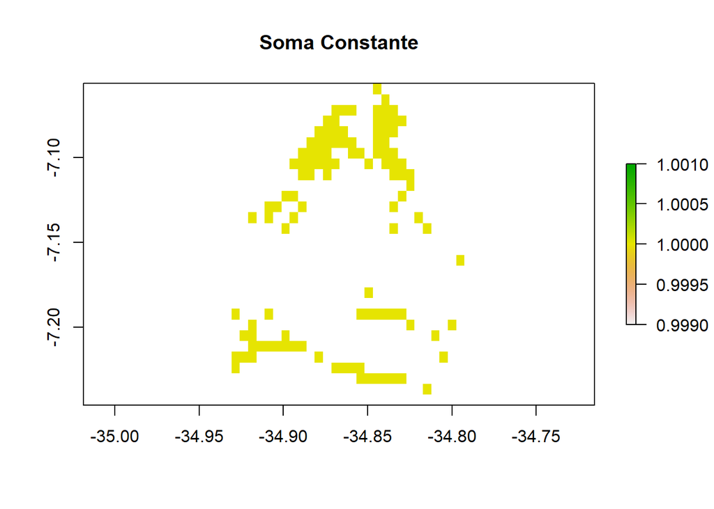

```r
# Criar um raster vazio com a mesma extensão e resolução que o original
raster_template <- raster(extent(poligonos), nrow=30, ncol=30)
crs(raster_template) <- CRS("+proj=longlat +datum=WGS84")

raster_from_polygons <- rasterize(poligonos, raster_template, field=1)

plot(raster_from_polygons, main="Soma Constante", xlim=c(xmin, xmax), ylim=c(ymin, ymax))
```

## **Análise Espacial**

Para iniciar uma análise espacial abrangente utilizando dados do Open Street Map (OSM) através da API Geofabrik, focada na região Nordeste do Brasil, no ambiente de programação R, podemos seguir uma abordagem sistemática que envolve várias etapas essenciais. Essas etapas nos permitirão extrair, processar e analisar dados geoespaciais , utilizando as capacidades do R para isso.

```r
# URL do arquivo shapefile da região Nordeste
#url <- "https://download.geofabrik.de/south-america/brazil/nordeste-latest-free.shp.zip"
#nome_arquivo <- "nordeste-latest-free.shp.zip"

# Baixar o arquivo shapefile
#options(timeout=300)
#download.file(url, destfile = nome_arquivo, mode = "wb", )
```

Após o download, utilizaremos a função unzip para extrair os arquivos shapefile, preparando-os para a leitura e manipulação no R.

```r
# Descompactar o arquivo
#nome_arquivo <- "nordeste-latest-free.shp.zip"
#unzip(nome_arquivo, exdir = "D:/Pos-GeoDataScience/M2-R/dado_pratica/nordeste-latest-free")
```

Com os dados descompactados, procederemos à leitura dos shapefiles usando a função `st_read`, como fizemos anteriormente.

```r
# Caminho para o arquivo shapefile desejado
caminho_shapefile <- "D:/Pos-GeoDataScience/M2-R/dado_pratica/nordeste-latest-free/gis_osm_pois_free_1.shp"

# Ler o shapefile
dados_osm <- st_read(caminho_shapefile)
restaurantes <- dados_osm %>% filter(fclass == "restaurant")
restaurantes <- st_transform(restaurantes, crs = 3857)
head(restaurantes)
```

```
## Simple feature collection with 6 features and 4 fields
## Geometry type: POINT
## Dimension:     XY
## Bounding box:  xmin: -4345163 ymin: -1666230 xmax: -3918469 ymax: -651212
## Projected CRS: WGS 84 / Pseudo-Mercator
##      osm_id code     fclass                         name
## 1 430453305 2301 restaurant                  Da Giovanni
## 2 501152457 2301 restaurant         Restaurante da APURN
## 3 501152491 2301 restaurant Restaurante da reitoria UFRN
## 4 501195378 2301 restaurant             Mirassol Lanches
## 5 501195402 2301 restaurant                Con Xin China
## 6 501195411 2301 restaurant                  Bari Palesi
##                     geometry
## 1  POINT (-4345163 -1666230)
## 2 POINT (-3918469 -651212.9)
## 3   POINT (-3918620 -651212)
## 4 POINT (-3919484 -651557.8)
## 5 POINT (-3918845 -652528.6)
## 6 POINT (-3918826 -652545.7)
```

### **Seleção Espacial**

Para realizar uma seleção espacial em R, podemos utilizar `st_within`. Este processo envolve filtrar um conjunto de dados espaciais, como pontos de interesse (por exemplo, restaurantes), com base na sua localização dentro de uma área específica (por exemplo, um município). Vamos também ajustar os sistemas de referência de coordenadas (CRS) para garantir a compatibilidade entre os conjuntos de dados.

Primeiro, precisamos garantir que ambos os conjuntos de dados, os pontos de interesse e a área de interesse (município específico), estejam no mesmo sistema de referência de coordenadas para realizar operações espaciais precisas.

```r
# Carregar dados geoespaciais
municipios <- st_read("D:/Pos-GeoDataScience/M2-R/dado_pratica/PB_Municipios/PB_Municipios_2022.shp")
joaoPessoa <- municipios %>% filter(municipios$NM_MUN == 'João Pessoa')
joaoPessoa <- st_transform(joaoPessoa, crs = 3857)
```

Agora, podemos usar a função `st_within` do pacote sf para realizar a seleção espacial, identificando os restaurantes que estão dentro do município específico.

```r
# Realizar a seleção espacial
indices <- st_within(restaurantes, joaoPessoa, sparse = FALSE)

# Filtrar os restaurantes que estão dentro de João Pessoa
restaurantes_joaoPessoa <- restaurantes[indices, ]
```

```r
head(restaurantes_joaoPessoa)
```

```
## Simple feature collection with 6 features and 4 fields
## Geometry type: POINT
## Dimension:     XY
## Bounding box:  xmin: -3877288 ymin: -797530.4 xmax: -3874684 ymax: -792958.1
## Projected CRS: WGS 84 / Pseudo-Mercator
##         osm_id code     fclass                     name
## 246 1330000526 2301 restaurant Corais Bar e Restaurante
## 248 1351960638 2301 restaurant        Kyoto Restaurante
## 515 1957132650 2301 restaurant        Nau Frutos do Mar
## 529 2014595894 2301 restaurant               Parmegiana
## 536 2022094181 2301 restaurant                   Monkey
## 555 2052041597 2301 restaurant         Adega do Alfredo
##                       geometry
## 246 POINT (-3874684 -797530.4)
## 248 POINT (-3876669 -795189.1)
## 515 POINT (-3877163 -793590.6)
## 529 POINT (-3876812 -793670.1)
## 536 POINT (-3876585 -793860.3)
## 555 POINT (-3877288 -792958.1)
```

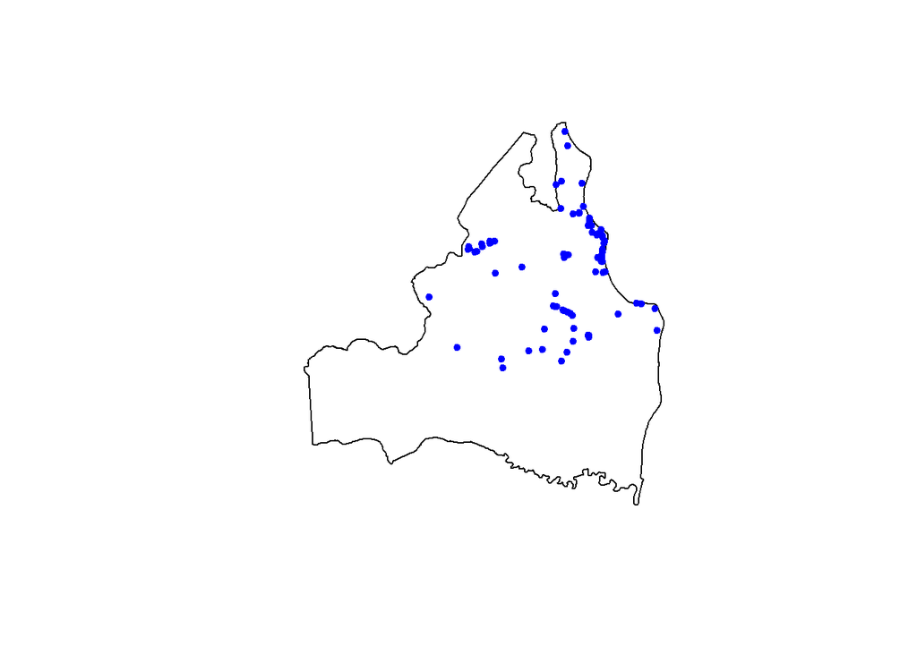

```r
# Usando o pacote sf para plotagem simples
plot(st_geometry(joaoPessoa))
plot(st_geometry(restaurantes_joaoPessoa), add = TRUE, col = 'blue', pch = 20)
```

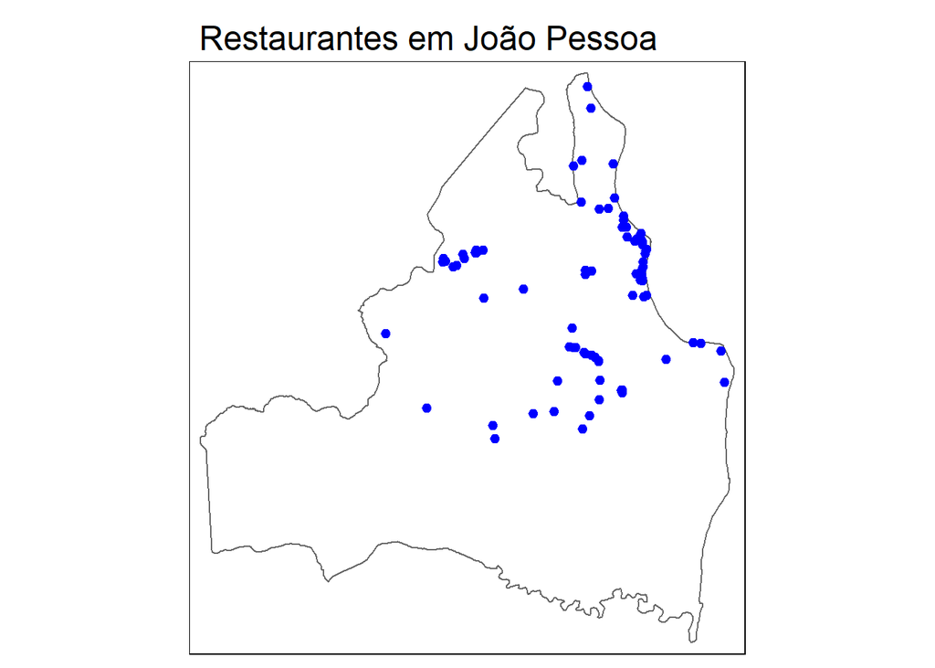

```r
#plotando com tmap
tm_shape(joaoPessoa) +
  tm_borders() +
  tm_shape(restaurantes_joaoPessoa) +
  tm_dots(col = "blue", size = 0.2) +
  tm_layout(main.title = "Restaurantes em João Pessoa")
```